# VisualizacionT1

Ricardo Garbanzo

January 29, 2020

# Ejercicio 1. [5 puntos]

### Con base en su experiencia indique posibles aplicaciones de la visualizacion de datos en su entono profecional asi como que tipo de visualizaciones espera poder desarrollar al analizar el curso.

### Respuesta

La metodologías de desarrollo de software que están de moda, los desarrolladores utilizan herramientas para estimar cuanto esfuerzo se puede tomar una tarea en ser completada. Esto es de suma importancia para determinar la velocidad con la que un desarrollador o equipo de desarrolladores pueden entregar un producto de valor para le empresa, por lo tanto un correcta estimación es de suma importancia. Al realizar un seguimiento de la estimación y compararlo con el valor real al final el periodo, podría generar información importante para los administradores de proyectos que permita mejorar el proceso de estimación o indentificar oportunidades de mejora.

# Ejercicio 2

## Explique de la forma mas detallada posible cada una de las lineas del siguiente codigo.

`library ( ggplot 2)` Carga de paquete para mapeado de variables

`library ( scales )` Carga de Paquete para re escalado de datos haciendo uso de las observaciones

`ggplot ( data = diamonds , mapping = aes (x = color )) +` ggplot permite indicar el dataframe por graficar y mapping permite especificar la informacion que conforma el plot, en este caso la variable color la cual es factor.

`geom _bar ( fill = " steelblue ") +` el paquete ggplopt permite sumar parametros que dan forma al grafico, en este caso se indica que se utilizaran barras para representar la cantidad de observaciones de la por cada categoria de la variable color en x.

`geom _ text ( mapping = aes ( label = comma ( stat ( count ))) , stat = " count ", vjust = -1) +` geom_text agrega una etiqueta al maping el cual es un conteo de la cantidad de observaciones por cada variable. De igual forma se indica que la etiqueta debe colocarse por arriba del mapeo.

`labs (y = " Cantidad de diamantes por color ",` se agrega una etiqueta al eje y para indicar cual es la informacion representada en ese eje.

`x = " Color ") +` se agregar informacion de la informacion representada en el eje x

`theme _ minimal ()`aplica un tema minimalista al grafico, en este caso el fondo transparente con cuadriculado

# Ejercicio 3

## 3. [25 puntos] Utilizando el paquete ggplot2 y el conjunto de datos agresores.csv el cual contiene la siguiente variables:

### a) Describa de forma detallada el graﬁco que quiere realizar.

Me interesa realizar un gráfico que permita visualizar la cantidad de casos por rango de edad y diferenciado entre los casos en que el agresor es hombre o mujer.

### b) Desarrolle el codigo en R necesario para poder realizar el graﬁco.

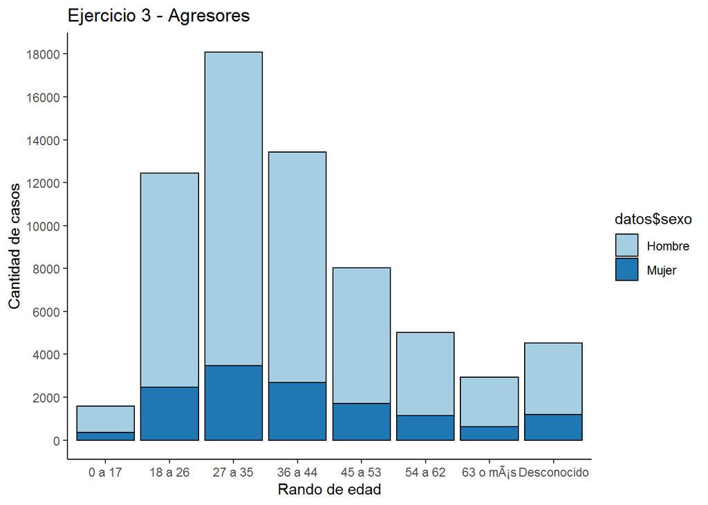

```r
library(ggplot2)
datos <- read.csv("agresores.csv", sep = ",")
ggplot(datos, aes(x=datos$rango_edad, y=datos$cantidad, fill=datos$sexo)) +
  geom_col(colour = "black") +
  scale_y_continuous(breaks = c(0,2000,4000,6000,8000,10000,12000,14000,16000,18000)) +
  labs(title = "Ejercicio 3 - Agresores", x = "Rando de edad", y = "Cantidad de casos") +
  theme_classic() +
  scale_fill_brewer(palette = "Paired")
```

### c) Describe linea por lınea el codigo presentado explicando que hacen cada una de las funciones.

`datos <- read.csv("agresores.csv", sep = ",")` Carga de datos agresor

`ggplot(datos, aes(x=datos$rango_edad, y=datos$cantidad, fill=datos$sexo)) +` se establece un plot con esteticas, rango de edad para el eje X y cantidad de casos para el eje Y. De igual forma se utiliza el parametro fill para establecer una diferencia de colores según la categoría sexo

`geom_col(colour = "black") +` Se utiliza para delinear las columnas con un color negro

`scale_y_continuous(breaks = c(0,2000,4000,6000,8000,10000,12000,14000,16000,18000)) +` Se modifica la escala del eje Y para tener una mejor referencia de cuanto representa cada columna según el rango.

`labs(title = "Ejercicio 3 - Agresores", x = "Rando de edad", y = "Cantidad de casos") +` Con esta linea se le agrega una etiqueta al eje X y al eje Y. Tambien se le aplica un titulo al gráfico.

`theme_classic() +` Se le aplica al plot un tema clásico el cual elimina el cuadriculado del fondo

`scale_fill_brewer(palette = "Paired")` aplica una paleta de colores pre establecidos al geom_col

# Ejercicio 4

## [25 puntos] Utilizando la tabla temperaturaEuropa.csv realice un analisis de componentes principales sobre las 12 primeras variables (12 meses del ano) y grafique, utilizando el paquete ggplot2, la distribucion de las ciudades en el plano principal utilizando las dos primeras componentes, el grafico debe cumplir los siguientes requisitos.

```r
datos <- read.csv("temperaturasEuropa.csv", sep = ";", header = T, row.names = 1)
str(datos)
```

```
## 'data.frame':    35 obs. of  17 variables:
##  $ Enero     : num  2.9 9.1 -0.2 3.3 -1.1 -0.4 4.8 -5.8 -5.9 -3.7 ...
##  $ Febrero   : num  2.5 9.7 0.1 3.3 0.8 -0.4 5 -6.2 -5 -2 ...
##  $ Marzo     : num  5.7 11.7 4.4 6.7 5.5 1.3 5.9 -2.7 -0.3 1.9 ...
##  $ Abril     : num  8.2 15.4 8.2 8.9 11.6 5.8 7.8 3.1 7.4 7.9 ...
##  $ Mayo      : num  12.5 20.1 13.8 12.8 17 11.1 10.4 10.2 14.3 13.2 ...
##  $ Junio     : num  14.8 24.5 16 15.6 20.2 15.4 13.3 14 17.8 16.9 ...
##  $ Julio     : num  17.1 27.4 18.3 17.8 22 17.1 15 17.2 19.4 18.4 ...
##  $ Agosto    : num  17.1 27.2 18 17.8 21.3 16.6 14.6 14.9 18.5 17.6 ...
##  $ Septiembre: num  14.5 23.8 14.4 15 16.9 13.3 12.7 9.7 13.7 13.7 ...
##  $ Octubre   : num  11.4 19.2 10 11.1 11.3 8.8 9.7 5.2 7.5 8.6 ...
##  $ Noviembre : num  7 14.6 4.2 6.7 5.1 4.1 6.7 0.1 1.2 2.6 ...
##  $ Diciembre : num  4.4 11 1.2 4.4 0.7 1.3 5.4 -2.3 -3.6 -1.7 ...
##  $ Media     : num  9.9 17.8 9.1 10.3 10.9 7.8 9.3 4.8 7.1 7.7 ...
##  $ Amplitud  : num  14.6 18.3 18.5 14.4 23.1 17.5 10.2 23.4 25.3 22.1 ...
##  $ Latitud   : num  52.2 37.6 52.3 50.5 47.3 55.4 53.2 60.1 50.3 50 ...
##  $ Longitud  : num  4.5 23.5 13.2 4.2 19 12.3 6.1 25 30.3 19.6 ...
##  $ Región    : Factor w/ 4 levels "Este","Norte",..: 3 4 3 3 1 2 2 2 1 1 ...
```

```r
library(FactoMineR)
resultado_acp <- PCA(datos[,1:12], graph = F)

# resultado_acp$ind$coord

# En este ruta se almacena la tabla con las coordenadas para los individuos

# agregamos a la tabla los nombres y las coordenadas de las primeras 2 componentes

datos_grafico <- data.frame(resultado_acp$ind$coord[,1:2])

# resultado_acp$ind$cos2 almacena el cos2 de cada uno de las componentes

# para tener el cos2 total sumamos los cos2 de las primeras dos componentes

datos_grafico <- cbind(datos_grafico, Cos2 = resultado_acp$ind$cos2[,1] + resultado_acp$ind$cos2[,2])

datos_grafico
```

```
##                      Dim.1       Dim.2      Cos2
## Ámsterdam       -0.5523548 -1.25040522 0.9305232
## Atenas           6.2839169  0.95822552 0.9905764
## Berlín          -1.0183078  0.03203312 0.8763152
## Bruselas        -0.1749397 -1.06604521 0.9626375
## Budapest         0.7980262  1.61252443 0.9252631
## Copenhague      -2.0978932 -0.41990238 0.9468726
## Dublín          -1.2293379 -2.47258779 0.9960829
## Helsinki        -4.4632047  0.46101087 0.9776465
## Kiev            -2.3209498  1.87947178 0.9895185
## Cracovia        -1.9119314  0.82769425 0.9781691
## Lisboa           4.4089706 -1.40084938 0.9975849
## Londres         -0.7024919 -1.44045222 0.9925791
## Madrid           3.0171501  0.73819440 0.9402422
## Minsk           -3.7317780  1.30063520 0.9947698
## Moscú           -3.9370601  2.03060672 0.9919738
## Oslo            -3.7936127  0.31633935 0.9924465
## París            0.5533502 -0.80094611 0.9305451
## Praga           -0.8458606  0.66829983 0.9329233
## Reikiavik       -5.1068670 -2.74927702 0.9986652
## Roma             4.2269909  0.34175293 0.9970941
## Sarajevo        -0.6059071  0.32017795 0.7265946
## Sofía           -0.3673643  0.76826771 0.8662456
## Estocolmo       -3.6481603  0.06154487 0.9521613
## Amberes         -0.2141274 -1.05404253 0.9451968
## Barcelona        4.7821542 -0.28098472 0.9951135
## Burdeos          1.8779357 -0.64636985 0.9805188
## Edimburgo       -1.9526867 -2.16781553 0.9959451
## Francfort       -0.3894077  0.15602717 0.4490760
## Ginebra         -0.4483883  0.18310083 0.6822948
## Génova           4.6523185 -0.03858978 0.9880759
## Milán            2.1730274  1.49240685 0.9768979
## Palermo          5.9869154 -0.17536077 0.9690629
## Sevilla          6.5182335  0.32563268 0.9973728
## San Petersburgo -4.4516798  1.52922942 0.9751259
## Zúrich          -1.3146785 -0.03954735 0.9200665
```

```r
# resultados_acp$eig contiene los valores propios de cada componente

# podemos saber la inercia explicada de cada componentes diviviendo su valor propio enter

# la cantidad de componentes

datos_grafico <- cbind(datos_grafico,
                       Iner.x = resultado_acp$eig[1,1]/nrow(resultado_acp$eig),
                       Iner.y = resultado_acp$eig[2,1]/nrow(resultado_acp$eig))



# Ahora tenemos los datos necesarios para poder hacer el gráfico


head(datos_grafico)
```

```
##                 Dim.1       Dim.2      Cos2    Iner.x    Iner.y
## Ámsterdam  -0.5523548 -1.25040522 0.9305232 0.8687044 0.1142082
## Atenas      6.2839169  0.95822552 0.9905764 0.8687044 0.1142082
## Berlín     -1.0183078  0.03203312 0.8763152 0.8687044 0.1142082
## Bruselas   -0.1749397 -1.06604521 0.9626375 0.8687044 0.1142082
## Budapest    0.7980262  1.61252443 0.9252631 0.8687044 0.1142082
## Copenhague -2.0978932 -0.41990238 0.9468726 0.8687044 0.1142082
```

## a) Representar sobre el plano cada una de las ciudades como un punto, adicionalmente un texto debe indicar el nombre de la cuidad.

## b) Las ciudades que tengan un valor de cos2 menor a 0,5 deben ser indicados utilizando el color rojo para el punto.

## c) Las etiquetas tanto en el eje x como y deben indicar la inercia explicada por el eje.

## d) El subtitulo del grafco debe indicar una pequena descripcion de los datos así como indicar el total de inercia explicada.

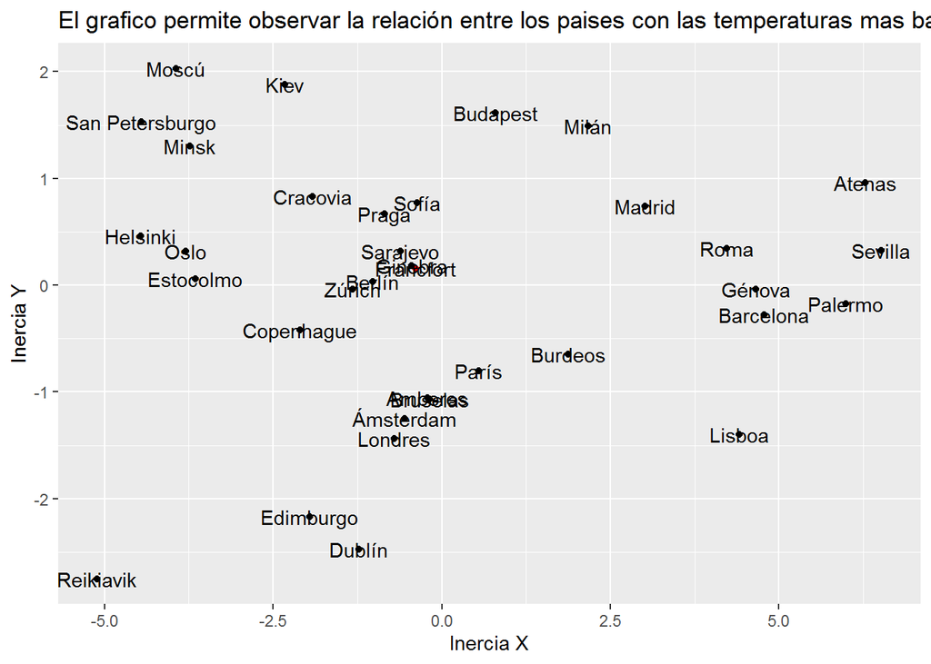

```r
library(ggplot2)

ggplot(datos_grafico, aes(x=datos_grafico$Dim.1, y=datos_grafico$Dim.2)) +
  geom_point(aes(color = ifelse(datos_grafico$Cos2 > 0.5, "black", "red")))+
  labs (y = datos_grafico$Iner.y,
        x = datos_grafico$Iner.x)+
  geom_text(mapping = aes(label = (row.names(datos_grafico))))+
  scale_color_identity()+
  labs(title = "El grafico permite observar la relación entre los paises con las temperaturas mas bajas.", x = "Inercia X", y = "Inercia Y")
```

# Ejercicio 5

## 5. [25 puntos] Utilizando datos propios cree 3 graficos distintos siguiendo las siguiente indicaciones para cada uno de ellos.

### a) Explique en que consisten los datos, asi como los tipos de variables que contiene la tabla.

### b) Identifique las variables que desea representar en el grafico.

### c) Seleccione un tipo de grafico y justifique porque considera es la mejor opcion para ese caso.

### d) Utilizando el paquete ggplot2 y todos los demas paquete que considere necesarios disene un grafico que permite mostrar de forma clara las variables seleccionadas.

### Grafico 1

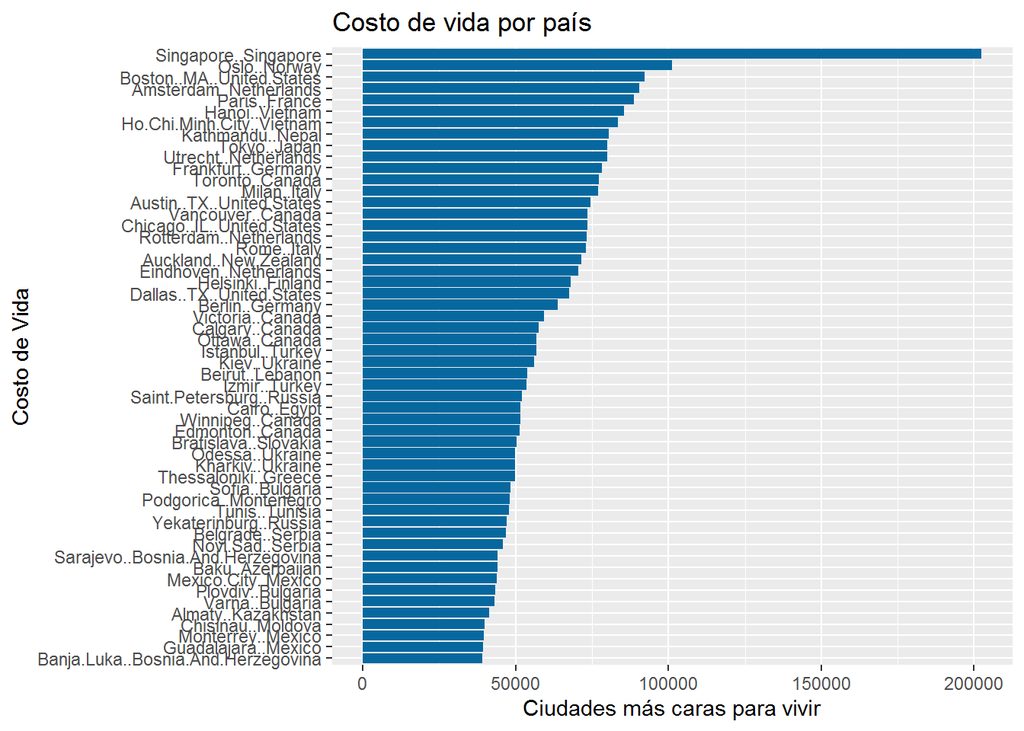

```r
library(forcats)
datos <- read.csv("cost-of-living.csv", sep = ",", header = T)
costoVida <- as.data.frame(colSums(datos[2:55]))
colnames(costoVida) <- "Monto"


ggplot(data = costoVida,
       mapping = aes(
         x = fct_reorder(rownames(costoVida), costoVida$Monto),
         y = costoVida$Monto)) +
  geom_col(fill = "#07689f") +
  coord_flip() +
  labs(title = "Costo de vida por país",
       x = "Costo de Vida",
       y = "Ciudades más caras para vivir" )
```

### Grafico 2

El data set de jugadores contiene la información de la plantilla de equipos de futbol europeo. En este caso mi interese fue hacer un análisis del promedio de edad de los jugadores así como el promedio del valor de los jugadores en el mercado de fichajes.

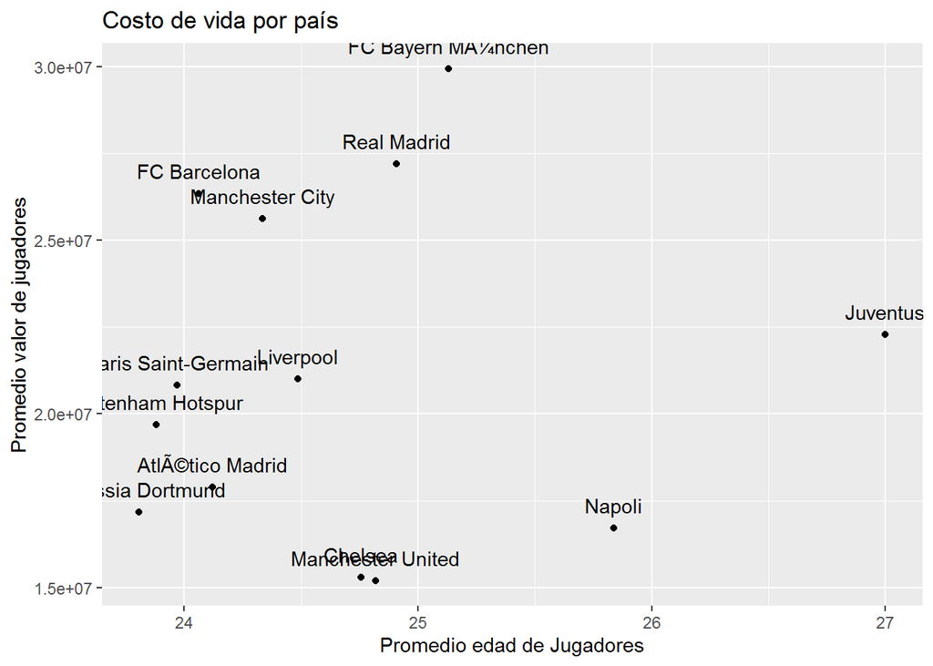

```r
library(dplyr)

datos <- read.csv("players_20.csv", sep = ",", header = T)
datos <- select(datos, 5, 10, 13)
suppressWarnings(dtMean <- aggregate(datos[,1:3], list(datos$club), mean))

DatosMean <- dtMean[order(dtMean$value_eur),]
DatosMean <- subset(DatosMean, DatosMean$value_eur > 14953667)


ggplot(data = DatosMean,
       mapping = aes(
         x = DatosMean$age,
         y = DatosMean$value_eur)) +
  geom_point() +
  labs(title = "Costo de vida por país",
       x = "Promedio edad de Jugadores",
       y = "Promedio valor de jugadores" )+
  geom_text (mapping = aes(label=(DatosMean$Group.1)), vjust = -1)
```

### Grafico 3

El data set de AppleStore permite ver la información de apps descargados para el sistemas operativo de IOS. Por lo tanto se plantea información de los apps como precio y user rating. Se utiliza el color para observar los tipos de aplicaciones descargadas dentro del rango de precio y user rating.

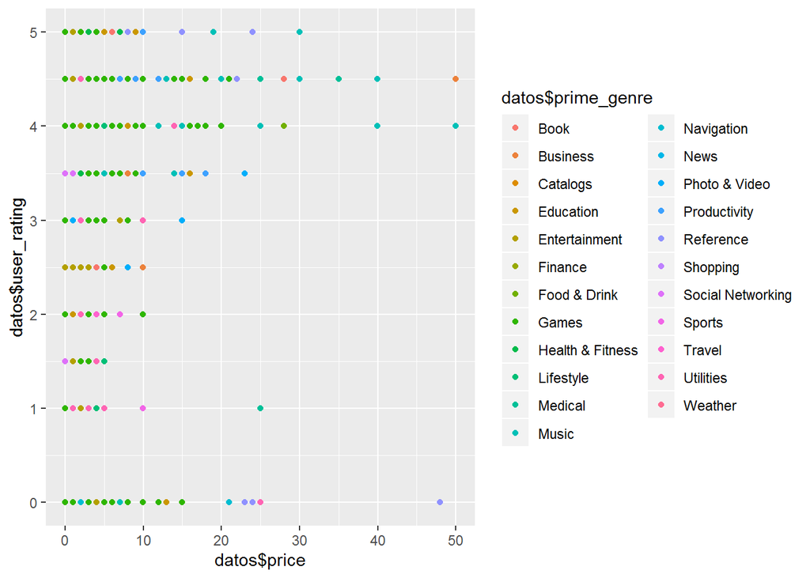

```r
library(ggplot2)
datos <- read.csv("AppleStore.csv", sep = ",", header = T)
datos <- select(datos, 6,9,13)
datos <- subset(datos, datos$price < 50)

ggplot(data = datos, mapping = aes(x = datos$price,y = datos$user_rating , color = datos$prime_genre)) +
  geom_point() +
  scale_x_continuous(breaks = c(-10,0,10,20,30,40,50))
```